# Nemotron 3.5 Streaming ASR

模型概述與中文 chunk-size 初步實驗

Nick · Speech Lab

2026-10-08

## 這次實驗在問什麼？

同一段中文音訊，  
改變 chunk 設定，辨識品質如何變化？

- **研究對象**：Nemotron 3.5 串流語音辨識模型。
- **比較設定**：80、160、320、560 ms。
- **評估指標**：字元錯誤率 CER；本次尚未測量實際延遲。

資料：既有實驗的終端截圖。本簡報整理既有結果，未重新執行 ASR 推論。

## 模型定位與架構

語音輸入，同語言文字輸出。

| 項目 | 模型卡中的描述 |
| --- | --- |
| **模型** | NVIDIA `nemotron-3.5-asr-streaming-0.6b` |
| **規模** | 約 6 億參數 |
| **架構** | Cache-aware FastConformer encoder（24 層） |
| **解碼與輸出** | RNN-T decoder＋語言提示；支援標點與大小寫 |

來源：[NVIDIA 官方模型卡](https://huggingface.co/nvidia/nemotron-3.5-asr-streaming-0.6b)。原報告查閱日：2026-10-08。

## 中文支援與語言提示

| 官方支援分級 | Language-locales | 使用方式 |
| --- | --- | --- |
| Transcription-ready | 19 | 可直接轉錄 |
| Broad-coverage | 13 | 可直接轉錄；包含 Mandarin `zh-CN` |
| Adaptation-ready | 8 | 需要微調 |

- `target_lang=zh-CN`：指定辨識語言。
- `target_lang=auto`：自動辨識語言。

40 個 locales 不等於 40 種獨立語言。  
官方支援表未單列 zh-TW，繁體輸出與台灣口音品質仍需驗證。

來源：[官方模型卡：語言支援與 NeMo 使用方式](https://huggingface.co/nvidia/nemotron-3.5-asr-streaming-0.6b)。

## 四組 chunk 的辨識結果

表 1: 不同 chunk 的結果；由使用者截圖轉錄，CER 以錯誤計數重新核算。

| Chunk | CER ↓ | S 替換 | D 刪除 | I 插入 | N 參考字數 |
| --- | --- | --- | --- | --- | --- |
| 80 ms | 18.60% | 8 | 0 | 0 | 43 |
| 160 ms | 16.28% | 7 | 0 | 0 | 43 |
| 320 ms | 16.28% | 7 | 0 | 0 | 43 |
| 560 ms | 13.95% | 6 | 0 | 0 | 43 |

本次最低 CER 出現在 **560 ms：13.95%**。相較 80 ms，降低 **4.65 個百分點**，相對 CER 降幅約 **25%**（以未四捨五入的計數計算）。

資料：原始截圖轉錄；表格與摘要由 data/chunk_results.csv 自動產生。

## Chunk 設定與 CER 的變化

[figure not shown]

80 到 560 ms：S 從 8 降到 6；D 與 I 都維持 0。  
本次 CER 的下降，來自少了 2 次替換錯誤。

橫軸是 chunk 設定，並非實測延遲；連線僅方便比較四個測試點。

## 結果解讀與錄音品質限制

- **本次觀察**：560 ms 的 CER 最低；160 與 320 ms 的總錯誤數相同。
- **可能影響因素**：測試音檔可能含環境音；錄音品質對辨識錯誤的影響仍待確認。
- **解讀範圍**：目前無法分辨 chunk 設定與噪音的影響，也無法判定中文辨識的最佳設定。

先檢查原始音檔、標記環境音片段；  
再以相同語音的乾淨／含噪版本，重測四組 chunk。

本次僅 43 個 reference 字元，差 1 次錯誤即約 2.33 個百分點。環境音影響為待驗證假設。

## 原始實驗截圖

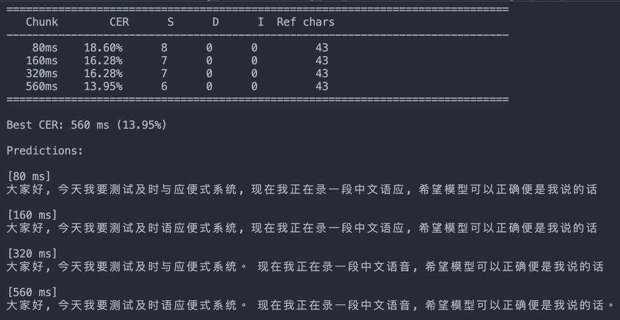

上方：CER 與錯誤計數。下方：各 chunk 的 predictions。  
保留完整原圖供核對；模型假設文字不等於人工標準答案。

## 下一輪：固定條件與中文評分

1. **固定比較條件**：保存音檔、人工 reference、模型版本、語言提示與解碼設定，每次只改 chunk。
2. **統一正規化**：記錄繁簡轉換、標點、空白、數字及語言標籤的處理方式。
3. **增加樣本**：涵蓋不同講者、專有名詞、中英夾雜與長句。

多音檔評估以總錯誤數 ÷ 總 reference 字數回報 corpus CER。

## 下一輪：量測延遲與串接翻譯

| 觀察項目 | 要記錄的內容 |
| --- | --- |
| **首字延遲** | 音訊到達與首次文字輸出的時間 |
| **穩定提交延遲** | 文字何時成為穩定輸出 |
| **尾端延遲** | 音訊結束至最後輸出的時間 |
| **RTF** | 處理耗時 / 音訊時長 |

加入 MT 後，再評估中文到英文的翻譯品質與完整系統延遲。

以上為下一輪實驗規劃；RTF 無法替代使用者感受到的延遲。

## 本次結論與下一步

560 ms 在此樣本的 CER 最低；  
設定選擇仍需更多音檔與延遲證據。

- **目前結果**：18.60% 降到 13.95%，少 2 次替換錯誤。
- **目前限制**：一段樣本、43 個 reference 字元、沒有實測延遲。
- **下一步**：固定評分方式，增加音檔並補上延遲記錄。

先確認辨識品質與等待時間，再決定翻譯系統的 chunk 設定。

## 資料與參考來源

1. **使用者提供的終端截圖**：本次所有實驗數字的來源，未混入官方 benchmark。
2. **[NVIDIA 官方模型卡](https://huggingface.co/nvidia/nemotron-3.5-asr-streaming-0.6b)**：模型架構、語言支援與 chunk 設定。原報告查閱日：2026-10-08。
3. **[Noroozi et al., ICASSP 2024](https://arxiv.org/abs/2312.17279)**：*Stateful Conformer with Cache-based Inference for Streaming Automatic Speech Recognition*；arXiv 初稿 2023。

架構研究作為 cache-aware 背景說明；不作為本次中文實驗結果的來源。